# TAE - Unit 5 - Recitation

GT

16 mai 2016

## Predictive Coding

We’ll be looking into how to use the text of emails in the inboxes of Enron executives to predict if those emails are relevant to an investigation.into the company.

We’ll be extracting word frequencies from the text of the documents, and then integrating those frequencies into predictive models.

### The Story of Enron

We’ll start with the story of Enron, the United States energy company based out of Houston, Texas that was involved in a number of electricity production and distribution markets.

In the early 2000s, Enron was a hot company, with a market capitalization exceeding $60 billion, and Forbes magazine ranked it as the most innovative US company six years in a row.

Now, all that changed in 2001 with the news of widespread accounting fraud at the firm. This massive fraud led to Enron’s bankruptcy, the largest ever at the time, and led to Enron’s accounting firm, Arthur Andersen, dissolving.

To this day, Enron remains a symbol of corporate greed and corruption.

Tthe firm also faced sanctions for its involvement in the California electricity crisis.

California is the most populous state in the United States. And in 2000 to 2001, it had a number of power blackouts, despite having sufficient generating capacity.

It later surfaced that Enron played a key role in this energy crisis by artificially reducing power supply to spike prices and then making a profit from this market instability.

The Federal Energy Regulatory Commission, or FERC, investigated Enron’s involvement in the crisis, and this investigation eventually led to a $1.52 billion settlement.

FERC’s investigation into Enron will be the topic of today’s recitation.

Enron was a huge company, and its corporate servers contained millions of emails and other electronic files. Sifting through these documents to find the ones relevant to an investigation is no simple task.

In law, this electronic document retrieval process is called the *eDiscovery* problem, and relevant files are called *responsive* documents.

Traditionally, the eDiscovery problem has been solved by using keyword search, in our case, perhaps, searching for phrases like “electricity bid” or “energy schedule”, followed by an expensive and time-consuming manual review process, in which attorneys read through thousands of documents to determine which ones are responsive.

However, *predictive coding* is a new technique, in which attorneys manually label some documents and then use text analytics models trained on the manually labeled documents to predict which of the remaining documents are responsive.

As part of its investigation, the FERC released hundreds of thousands of emails from top executives at Enron creating the largest publicly available set of emails today.

We will use this data set called the Enron Corpus to perform predictive coding in this recitation.

The data set contains just two fields:

- *email*, which is the text of the email in question
- *responsive*, which is whether the email relates to energy schedules or bids.

The labels for these emails were made by attorneys as part of the 2010 text retrieval conference legal track, a predictive coding competition.

### The Data

Let’s begin by creating a data frame called emails using the read.csv function. And as always, in the text analytics week, we’re going to pass stringsAsFactors=FALSE to this function.

```r
emails = read.csv("energy_bids.csv", stringsAsFactors = FALSE)
str(emails)
```

```
## 'data.frame':    855 obs. of  2 variables:
##  $ email     : chr  "North America's integrated electricity market requires cooperation on environmental policies Commission for Environmental Coope"| __truncated__ "FYI -----Original Message----- From: \t\"Ginny Feliciano\" <gfeliciano@earthlink.net>@ENRON [mailto:IMCEANOTES-+22Ginny+20Felic"| _…
##  $ responsive: int  0 1 0 1 0 0 1 0 0 0 ...
```

We can see that there are 855 observations. This means we have 855 labeled emails in the data set. And for each one we have the text of the email and whether or not it’s responsive to our query about energy schedules and bids.

So let’s take a look at a few example emails in the data set, starting with the first one.

```r
emails$email[1]
```

```
## [1] "North America's integrated electricity market requires cooperation on environmental policies Commission for Environmental Cooperation releases working paper on North America's electricity market Montreal, 27 November 2001 -- The North American Commission for Environmental Cooperation (CEC) i…
```

```r
# the strwrap function brakes down the long string into multiple shorter lines that are easier to read
strwrap(emails$email[1])
```

```
##  [1] "North America's integrated electricity market requires cooperation"
##  [2] "on environmental policies Commission for Environmental Cooperation"
##  [3] "releases working paper on North America's electricity market"
##  [4] "Montreal, 27 November 2001 -- The North American Commission for"
##  [5] "Environmental Cooperation (CEC) is releasing a working paper"
##  [6] "highlighting the trend towards increasing trade, competition and"
##  [7] "cross-border investment in electricity between Canada, Mexico and"
##  [8] "the United States. It is hoped that the working paper,"
##  [9] "Environmental Challenges and Opportunities in the Evolving North"
## [10] "American Electricity Market, will stimulate public discussion"
## [11] "around a CEC symposium of the same title about the need to"
## [12] "coordinate environmental policies trinationally as a North"
## [13] "America-wide electricity market develops. The CEC symposium will"
## [14] "take place in San Diego on 29-30 November, and will bring together"
## [15] "leading experts from industry, academia, NGOs and the governments"
```

[output cut: 74 more lines]

We can see just by parsing through the first couple of lines that this is an email that’s talking about a new working paper, “The Environmental Challenges and Opportunities in the Evolving North American Electricity Market” is the name of the paper. And it’s being released by the Commission for Environmental Cooperation, or CEC.

So while this certainly deals with electricity markets, it doesn’t have to do with energy schedules or bids. So *it is not responsive to our query*.

So we can take a look at the value in the responsive variable

```r
emails$responsive[1]
```

```
## [1] 0
```

So let’s take a look at the second email in our data set.

```r
strwrap(emails$email[2])
```

```
##  [1] "FYI -----Original Message----- From: \"Ginny Feliciano\""
##  [2] "<gfeliciano@earthlink.net>@ENRON"
##  [3] "[mailto:IMCEANOTES-+22Ginny+20Feliciano+22+20+3Cgfeliciano+40earthlink+2Enet+3E+40ENRON@ENRON.com]"
##  [4] "Sent: Thursday, June 28, 2001 3:40 PM To: Silvia Woodard; Paul"
##  [5] "Runci; Katrin Thomas; John A. Riggs; Kurt E. Yeager; Gregg Ward;"
##  [6] "Philip K. Verleger; Admiral Richard H. Truly; Susan Tomasky;"
##  [7] "Tsutomu Toichi; Susan F. Tierney; John A. Strom; Gerald M. Stokes;"
##  [8] "Kevin Stoffer; Edward M. Stern; Irwin M. Stelzer; Hoff Stauffer;"
##  [9] "Steven R. Spencer; Robert Smart; Bernie Schroeder; George A."
## [10] "Schreiber, Jr.; Robert N. Schock; James R. Schlesinger; Roger W."
## [11] "Sant; John W. Rowe; James E. Rogers; John F. Riordan; James"
## [12] "Ragland; Frank J. Puzio; Tony Prophet; Robert Priddle; Michael"
## [13] "Price; John B. Phillips; Robert Perciasepe; D. Louis Peoples;"
## [14] "Robert Nordhaus; Walker Nolan; William A. Nitze; Kazutoshi"
## [15] "Muramatsu; Ernest J. Moniz; Nancy C. Mohn; Callum McCarthy; Thomas"
```

[output cut: 19 more lines]

And scrolling up to the top here we can see that the original message is actually very short, it just says FYI (For Your Information), and most of it is a forwarded message.

So we have all the people who originally received the message. And then down at the very bottom is the message itself. “Attached is my report prepared on behalf of the California State auditor.” And there’s an attached report, ca report `new.pdf`. Now our data set contains just the text of the emails and not the text of the attachments.

But it turns out, as we might expect, that this attachment had to do with Enron’s electricity bids in California, and therefore it is responsive to our query.

And we can check this in the responsive variable.

```r
emails$responsive[2]
```

```
## [1] 1
```

So now let’s look at the breakdown of the number of emails that are responsive to our query using the table function.

```r
table(emails$responsive)
```

```
##
##   0   1
## 716 139
```

And as we can see the data set is unbalanced, with a relatively small proportion of emails responsive to the query.

*This is typical in predictive coding problems*.

### Pre-Processing

Now it’s time to construct and preprocess the corpus.

So we’ll start by loading the tm package and SnowballC package.

```r
library(tm)
library(SnowballC)
```

And now that we’ll have done that, we’ll construct a variable called corpus using the Corpus and VectorSource functions and passing in all the emails in our data set.

```r
corpus = Corpus(VectorSource(emails$email))
strwrap(corpus[[1]]$content)
```

```
##  [1] "North America's integrated electricity market requires cooperation"
##  [2] "on environmental policies Commission for Environmental Cooperation"
##  [3] "releases working paper on North America's electricity market"
##  [4] "Montreal, 27 November 2001 -- The North American Commission for"
##  [5] "Environmental Cooperation (CEC) is releasing a working paper"
##  [6] "highlighting the trend towards increasing trade, competition and"
##  [7] "cross-border investment in electricity between Canada, Mexico and"
##  [8] "the United States. It is hoped that the working paper,"
##  [9] "Environmental Challenges and Opportunities in the Evolving North"
## [10] "American Electricity Market, will stimulate public discussion"
## [11] "around a CEC symposium of the same title about the need to"
## [12] "coordinate environmental policies trinationally as a North"
## [13] "America-wide electricity market develops. The CEC symposium will"
## [14] "take place in San Diego on 29-30 November, and will bring together"
## [15] "leading experts from industry, academia, NGOs and the governments"
```

[output cut: 74 more lines]

And we can see that this is exactly the same email that we saw originally, the email about the working paper.

So now we’re ready to preprocess the corpus using the tm_map function. First, we’ll convert the corpus to lowercase using tm_map and the tolower function.

```r
corpus = tm_map(corpus, content_transformer(tolower))
corpus = tm_map(corpus, PlainTextDocument)
```

Then we’ll do the exact same thing except removing punctuation

```r
corpus = tm_map(corpus, removePunctuation)
```

We’ll remove the stop words with

```r
length(stopwords("english"))
```

```
## [1] 174
```

```r
corpus = tm_map(corpus, removeWords, stopwords("english"))
```

And lastly, we’re going to stem the document.

```r
corpus = tm_map(corpus, stemDocument)
```

Now that we’ve gone through those four preprocessing steps, we can take a second look at the first email in the corpus.

```r
strwrap(corpus[[1]]$content)
```

```
##  [1] "north america integr electr market requir cooper environment"
##  [2] "polici commiss environment cooper releas work paper north america"
##  [3] "electr market montreal 27 novemb 2001 north american commiss"
##  [4] "environment cooper cec releas work paper highlight trend toward"
##  [5] "increas trade competit crossbord invest electr canada mexico unit"
##  [6] "state hope work paper environment challeng opportun evolv north"
##  [7] "american electr market will stimul public discuss around cec"
##  [8] "symposium titl need coordin environment polici trinat north"
##  [9] "americawid electr market develop cec symposium will take place san"
## [10] "diego 2930 novemb will bring togeth lead expert industri academia"
## [11] "ngos govern canada mexico unit state consid impact evolv continent"
## [12] "electr market human health environ goal work paper symposium"
## [13] "highlight key environment issu must address electr market north"
## [14] "america becom integr said janin ferretti execut director cec want"
## [15] "stimul discuss around import polici question rais countri can"
```

[output cut: 44 more lines]

And now it looks quite a bit different. It’s a lot harder to read now that we removed all the stop words and punctuation and word stems, but now the emails in this corpus are ready for our machine learning algorithms.

### Bag of Words

Now let’s build the document-term matrix for our corpus.

```r
dtm = DocumentTermMatrix(corpus)
dtm
```

```
## <<DocumentTermMatrix (documents: 855, terms: 21735)>>
## Non-/sparse entries: 102511/18480914
## Sparsity           : 99%
## Maximal term length: 113
## Weighting          : term frequency (tf)
```

What we can see is that even though we have only 855 emails in the corpus, we have almost 22,000 terms that showed up at least once, which is clearly too many variables for the number of observations we have.

So we want to remove the terms that don’t appear too often in our data set, and we’ll do that using the removeSparseTerms function.

```r
dtm = removeSparseTerms(dtm, 0.97) # remove any term that doesn't appear in at least 3% of documents
dtm
```

```
## <<DocumentTermMatrix (documents: 855, terms: 788)>>
## Non-/sparse entries: 51644/622096
## Sparsity           : 92%
## Maximal term length: 19
## Weighting          : term frequency (tf)
```

We can see that we’ve decreased the number of terms to 788, which is a much more reasonable number.

So let’s build a data frame called labeledTerms out of this document-term matrix.

```r
labeledTerms = as.data.frame(as.matrix(dtm))
```

So this data frame is only including right now the frequencies of the words that appeared in at least 3% of the documents, but in order to run our text analytics models, we’re also going to have the outcome variable, which is whether or not each email was responsive.

So we need to add in this outcome variable.

```r
labeledTerms$responsive = emails$responsive
str(labeledTerms)
```

```
## 'data.frame':    855 obs. of  789 variables:
##  $ 100                : num  0 0 0 0 0 0 5 0 0 0 ...
##  $ 1400               : num  0 0 0 0 0 0 0 0 0 0 ...
##  $ 1999               : num  0 0 0 0 0 0 0 0 0 0 ...
##  $ 2000               : num  0 0 1 0 1 0 6 0 1 0 ...
##  $ 2001               : num  2 1 0 0 0 0 7 0 0 0 ...
##  $ 713                : num  0 0 0 0 0 0 0 0 0 0 ...
##  $ 77002              : num  0 0 0 0 0 0 0 0 0 0 ...
##  $ abl                : num  0 0 0 0 0 0 2 0 0 0 ...
##  $ accept             : num  0 0 0 0 0 0 1 0 0 0 ...
##  $ access             : num  0 0 0 0 0 0 0 0 0 0 ...
##  $ accord             : num  0 0 0 0 0 0 1 0 0 0 ...
##  $ account            : num  0 0 0 0 0 0 3 0 0 0 ...
##  $ act                : num  0 0 0 0 0 0 1 0 0 0 ...
##  $ action             : num  0 0 0 0 1 0 0 0 0 0 ...
```

[output cut: 86 more lines]

So as we expect, there are an awful lot of variables, 789 in total. 788 of those variables are the frequencies of various words in the emails, and the last one is responsive, the outcome variable.

### Building Models

At long last, we’re ready to split our data into a training and testing set, and to actually build a model.

```r
library(caTools)
set.seed(144)
split = sample.split(labeledTerms$responsive, 0.7)
train = subset(labeledTerms, split == TRUE)
test = subset(labeledTerms, split == FALSE)
```

Now we’re ready to build the model. And we’ll build a simple CART model using the default parameters. But a random forest would be another good choice from our toolset.

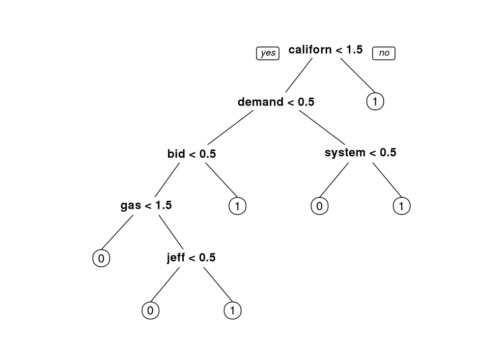

```r
library(rpart)
library(rpart.plot)
emailCART = rpart(responsive~., data=train, method="class")
prp(emailCART)
```

So we can see at the very top is the word California. If California appears at least twice in an email, we’re going to take the right part over here and predict that a document is responsive.

It’s somewhat unsurprising that California shows up, because we know that Enron had a heavy involvement in the California energy markets.

So further down the tree, we see a number of other terms that we could plausibly expect to be related to energy bids and energy scheduling, like system, demand, bid, and gas.

Down here at the bottom is Jeff, which is perhaps a reference to Enron’s CEO, Jeff Skillings, who ended up actually being jailed for his involvement in the fraud at the company.

### Evaluating the Model

Now that we’ve trained a model, we need to evaluate it on the test set.

So let’s build an object called pred that has the predicted probabilities for each class from our CART model.

```r
pred = predict(emailCART, newdata = test)
pred[1:10,] # look at the first 10 rows and all columns
```

```
##                        0          1
## character(0)   0.2156863 0.78431373
## character(0).1 0.9557522 0.04424779
## character(0).2 0.9557522 0.04424779
## character(0).3 0.8125000 0.18750000
## character(0).4 0.4000000 0.60000000
## character(0).5 0.9557522 0.04424779
## character(0).6 0.9557522 0.04424779
## character(0).7 0.9557522 0.04424779
## character(0).8 0.1250000 0.87500000
## character(0).9 0.1250000 0.87500000
```

The left column here is the predicted probability of the document being non-responsive. And the right column is the predicted probability of the document being responsive. They sum to 1.

In our case, we want to extract the predicted probability of the document being responsive. So we’re looking for the rightmost column.

```r
pred.prob = pred[, 2]
table(test$responsive, pred.prob >= 0.5)
```

```
##
##     FALSE TRUE
##   0   195   20
##   1    17   25
```

```r
# accuracy
(195+25) / (195 + 25 + 20 + 17)
```

```
## [1] 0.8560311
```

What we can see here is that in 195 cases, we predict false when the left column and the true outcome was zero, non-responsive. So we were correct. And in another 25, we correctly identified a responsive document.

In 20 cases, we identified a document as responsive, but it was actually non-responsive. And in 17, the opposite happened. We identified a document as non-responsive, but it actually was responsive.

So we have an accuracy in the test set of 85.6%.

And now we want to compare ourselves to the accuracy of the baseline model.

As we’ve already established, the baseline model is always going to predict the document is non-responsive.

```r
table(test$responsive)
```

```
##
##   0   1
## 215  42
```

```r
# accuracy baseline
215/(215 + 42)
```

```
## [1] 0.8365759
```

So that’s 83.7% accuracy.

So we see just a small improvement in accuracy using the CART model, which, as we know, is a common case in unbalanced data sets.

However, as in most document retrieval applications, there are uneven costs for different types of errors here.

Typically, a human will still have to manually review all of the predicted responsive documents to make sure they are actually responsive.

Therefore, if we have a false positive, in which a non-responsive document is labeled as responsive, the mistake translates to a bit of additional work in the manual review process but no further harm, since the manual review process will remove this erroneous result.

But on the other hand, if we have a false negative, in which a responsive document is labeled as non-responsive by our model, we will miss the document entirely in our predictive coding process.

Therefore, we’re going to assign a higher cost to false negatives than to false positives, which makes this a good time to look at other cut-offs on our ROC curve.

### The ROC Curve

Now let’s look at the ROC curve so we can understand the performance of our model at different cutoffs.

```r
library(ROCR)
```

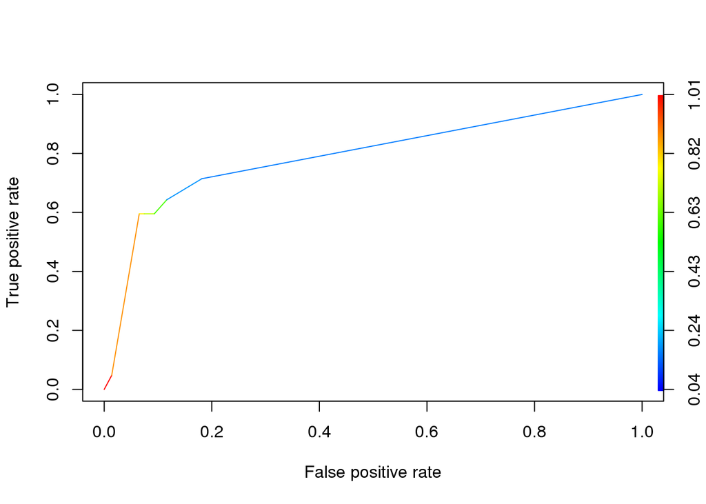

```r
predROCR = prediction(pred.prob, test$responsive)
perfROCR = performance(predROCR, "tpr", "fpr") # to extract the true positive rate and false positive rate
plot(perfROCR, colorize=TRUE)
```

Now, of course, the best cutoff to select is entirely dependent on the costs assigned by the decision maker to false positives and true positives.

However, again, we do favor cutoffs that give us a high sensitivity. We want to identify a large number of the responsive documents.

So something that might look promising might be a point where we have a true positive rate of around 70%, meaning that we’re getting about 70% of all the responsive documents, and a false positive rate of about 20%, meaning that we’re making mistakes and accidentally identifying as responsive 20% of the non-responsive documents.

Now, since, typically, the vast majority of documents are non-responsive, operating at this cutoff would result, perhaps, in a large decrease in the amount of manual effort needed in the eDiscovery process. And we can see from the blue color of the plot at this particular location that we’re looking at a threshold around maybe 0.15 or so, significantly lower than 50%, which is definitely what we would expect since we favor false positives to false negatives.

Lastly, we can use the ROCR package to compute our AUC value.

```r
performance(predROCR, "auc")@y.values
```

```
## [[1]]
## [1] 0.7936323
```

We can see that we have an AUC in the test set of 79.4%, which means that our model can differentiate between a randomly selected responsive and non-responsive document about 80% of the time.

### Predictive Coding Today

Let’s conclude with a word about the status of predictive coding today. In legal systems, it’s difficult to change existing practice because of laws reliance on past precedent, which causes current decisions to be made on the basis of past ones.

Because the types of eDiscovery admissible in court have historically been limited to keyword search coupled with manual review, nearly all cases today use this eDiscovery approach.

However, this status quo seems to be starting to change. In 2012, a US District Court ruled that predictive coding was a legitimate eDiscovery tool, which may pave the way for its expanded use in coming years.